# Lab 06 – Solutions: Explaining MHV Change

## Visualizations

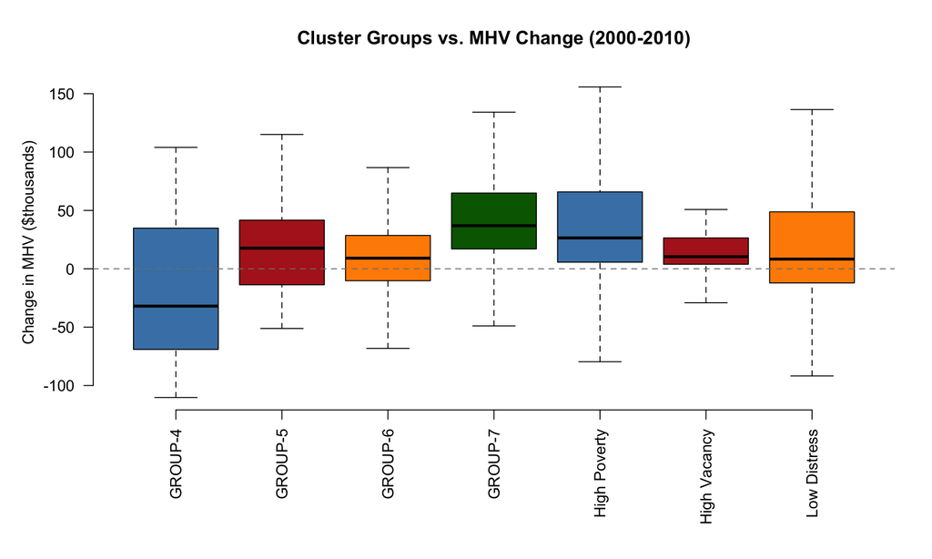

```r
par( mar = c( 8, 5, 4, 2 ) )

plot( d3$cluster.group, d3$mhv.change / 1000,
      las = 2, frame.plot = FALSE, outline = FALSE,
      main = "Cluster Groups vs. MHV Change (2000-2010)",
      xlab = "", ylab = "Change in MHV ($thousands)",
      col = c( "steelblue", "firebrick", "darkorange", "darkgreen" ) )

abline( h = 0, col = "gray50", lty = 2 )
```

The box plot shows that the distribution of MHV changes differs substantially across neighborhood types. The dashed horizontal line at $0 shows the break-even point. Groups with boxes entirely above this line experienced predominantly positive growth; groups straddling or below the line include tracts that lost value.

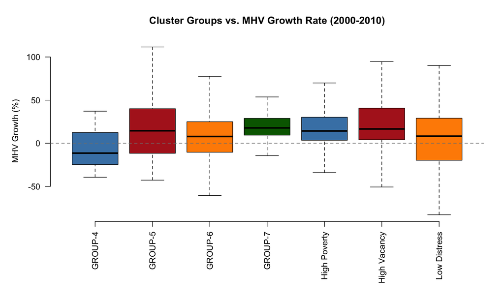

```r
par( mar = c( 8, 5, 4, 2 ) )

plot( d3$cluster.group, d3$mhv.growth,
      las = 2, frame.plot = FALSE, outline = FALSE,
      main = "Cluster Groups vs. MHV Growth Rate (2000-2010)",
      xlab = "", ylab = "MHV Growth (%)",
      col = c( "steelblue", "firebrick", "darkorange", "darkgreen" ) )

abline( h = 0, col = "gray50", lty = 2 )
```

## Summary Table

```r
group.results <- d3 %>%
  group_by( cluster.group ) %>%
  summarise(
    N               = n(),
    Mean.MHV.Change = dollar( round( mean( mhv.change, na.rm = TRUE ), 0 ) ),
    Mean.MHV.Growth = paste0( round( mean( mhv.growth, na.rm = TRUE ), 1 ), "%" )
  )

knitr::kable( group.results,
              caption = "Average MHV Change by Neighborhood Cluster Type (2000-2010)",
              align = "lrrr" )
```

Average MHV Change by Neighborhood Cluster Type (2000-2010)

| cluster.group | N | Mean.MHV.Change | Mean.MHV.Growth |
| --- | --- | --- | --- |
| GROUP-4 | 9 | -$13,573 | -4.8% |
| GROUP-5 | 60 | $26,863 | 22% |
| GROUP-6 | 216 | $11,086 | 8.7% |
| GROUP-7 | 76 | $48,327 | 19.7% |
| High Poverty | 410 | $45,265 | 19.2% |
| High Vacancy | 76 | $14,934 | 21.3% |
| Low Distress | 119 | $21,468 | 10.2% |

# Conclusion

This lab demonstrated three approaches to analyzing neighborhood change:

1. **Prediction with 2000 levels** (Part 2): Cross-sectional indicators of neighborhood distress in 2000 are statistically significant predictors of subsequent home value change. However, the coefficients are vulnerable to omitted variable bias and should not be interpreted causally.
2. **Explanation with changes in X** (Part 3): By focusing on how changes in unemployment, vacancy, and poverty *over time* relate to changes in home values, we move closer to causal inference. This specification controls for time-invariant unobserved factors.
3. **Prediction with neighborhood types** (Part 4): Cluster-based neighborhood typologies provide a parsimonious way to summarize tract conditions and predict future trajectories. Knowing a tract’s “type” in 2000 helps forecast its home value path over the following decade.

The key takeaway is the distinction between **prediction** and **explanation**: the same regression framework can serve different purposes depending on whether we use levels or changes as covariates. For policy analysis, the explanatory framework (Part 3) is more useful because it helps identify the *drivers* of change, though identifying a driver is not the same as identifying a feasible policy lever.